# prac

Rigam bhaduri

2025-06-08

##Generation of Uniform random numbers in the interval [0,1]

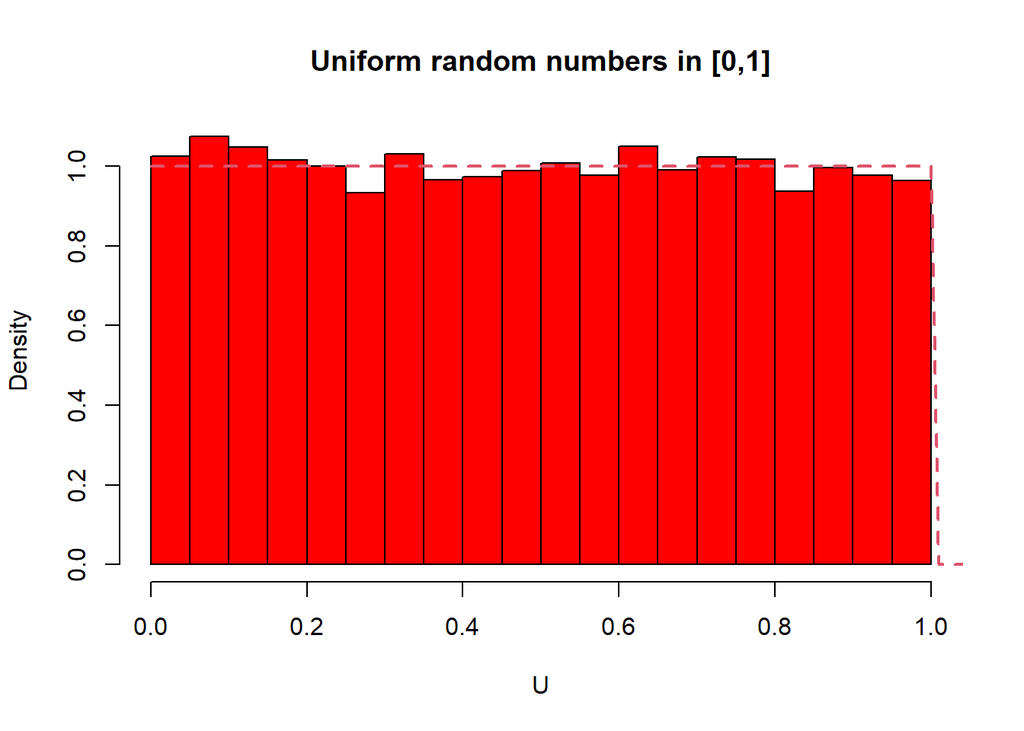

```r
#Uniform Distribution

n <- 10000
U <- runif(n,min = 0,max = 1)
hist(U,main = "Uniform random numbers in [0,1]",probability = 1, col = "red")
s<-seq(0,10,by=0.01)
d<-dunif(s,min =0, max = 1)
lines(d~s,col=2, lwd=2, lty=2)
```

# Data generation from $Exponential(\lambda)$ When $X\sim U(0,1)$ then $y=-\frac{1}{\lambda}\log(1-x)$ follows $Exp(\lambda)$ for ant rate parameter $\lambda>0$.

$\textbf{1. Uniform Random Variable Generation}$ The code generates $n = 10,\!000$ independent uniform random variables:

x = runif(n = 10000, min = 0, max = 1)

Mathematically, this represents:
$$X_i \sim \mathcal{U}(0,1), \quad \text{for } i = 1,2,\ldots,10000$$
where each $X_i$ has probability density function (PDF):
$$f_X(x) =
\begin{cases}
1 & \text{if } 0 \leq x \leq 1 \\
0 & \text{otherwise}
\end{cases}$$

$\textbf{2. Exponential Transformation}$ The transformation to exponential random variables with rate $\lambda = 3$ is:

lambda <- 3 y = -(1/lambda)*log(1 - x)

This uses the inverse transform method. For an exponential distribution with rate $\lambda$, the: 1. Cumulative Distribution Function (CDF):
$$F_Y(y) = 1 - e^{-\lambda y}, \quad y \geq 0$$

2. Inverse CDF:
   $$F_Y^{-1}(u) = -\frac{1}{\lambda}\ln(1 - u), \quad 0 \leq u \leq 1$$

Thus each transformed variable is:
$$Y_i = F_Y^{-1}(X_i) = -\frac{1}{\lambda}\ln(1 - X_i)$$

$\textbf{3. Theoretical Justification}$ Since $X \sim \mathcal{U}(0,1)$, then:
$$Y = -\frac{1}{\lambda}\ln(X) \sim \text{Exp}(\lambda)$$
because:
$$\begin{align*}
P(Y \leq y) &= P\left(-\frac{1}{\lambda}\ln(X) \leq y\right) \\
&= P\left(\ln(X) \geq -\lambda y\right) \\
&= P\left(X \geq e^{-\lambda y}\right) \\
&= 1 - e^{-\lambda y}
\end{align*}$$
which is exactly the CDF of an exponential distribution.

Comparing:

1. Empirical distribution (histogram) of the generated $Y_i$ values
2. Theoretical exponential PDF:
   $$f_Y(y) = \lambda e^{-\lambda y}, \quad y \geq 0$$

The alignment between histogram and theoretical curve validates the transformation.

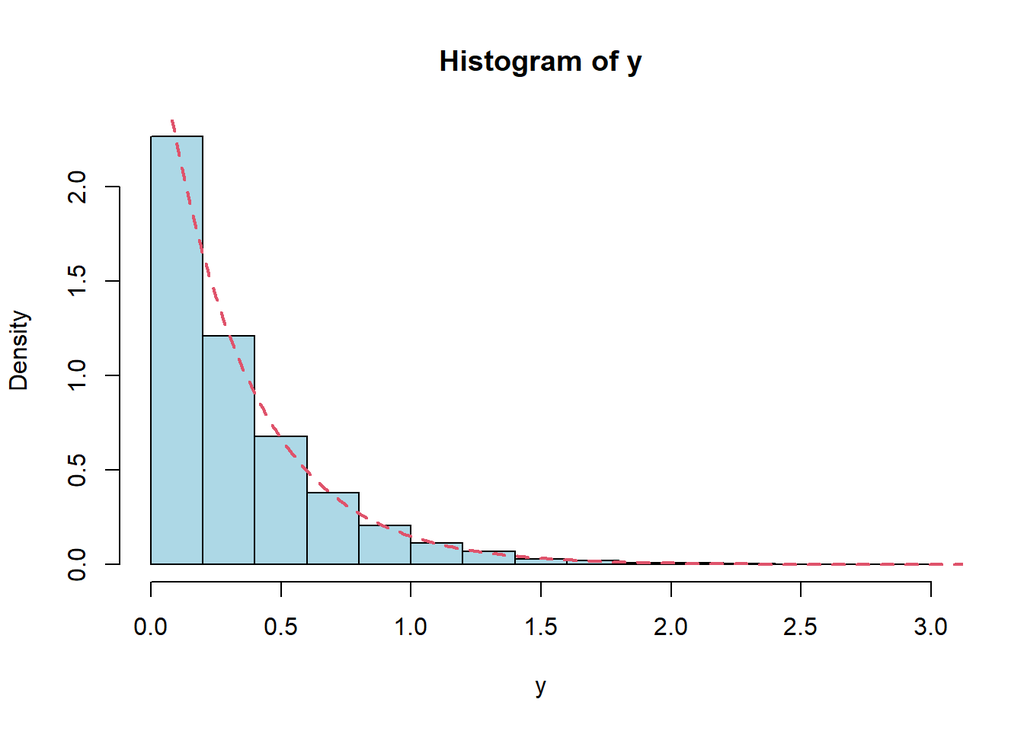

```r
x=runif(n=10000,min = 0,max = 1)
lambda<-3 # rate parameter
y=-(1/lambda)*log(1-x) # transformation
hist(y,probability = TRUE,col = "lightblue")
s<-seq(0,10,by=0.01)
dexpo<-dexp(s,rate = lambda) # density function
lines(dexpo~s, col=2, lwd=2, lty=2)
```

$\textbf{Generating Gamma-Distributed Random Variables}$

1. Exponential($\lambda$) from Uniform(0,1)} If $X \sim \text{Uniform}(0,1)$, then:
   $$Y = -\frac{1}{\lambda} \ln(1 - X) \sim \text{Exponential}(\lambda)$$
2. Gamma($n, \lambda$) from Sum of Exponentials If $Y_1, Y_2, \dots, Y_n \overset{\text{i.i.d.}}{\sim} \text{Exponential}(\lambda)$, then:
   $$Z = \sum_{i=1}^n Y_i \sim \text{Gamma}(n, \lambda)$$

$\textbf{Mathematical Justification}$

1. The CDF of $\text{Exponential}(\lambda)$ is $F(y) = 1 - e^{-\lambda y}$.
2. Its inverse CDF is $F^{-1}(u) = -\frac{1}{\lambda} \ln(1 - u)$.
3. The sum of $n$ i.i.d. exponential variables follows $\text{Gamma}(n, \lambda)$.

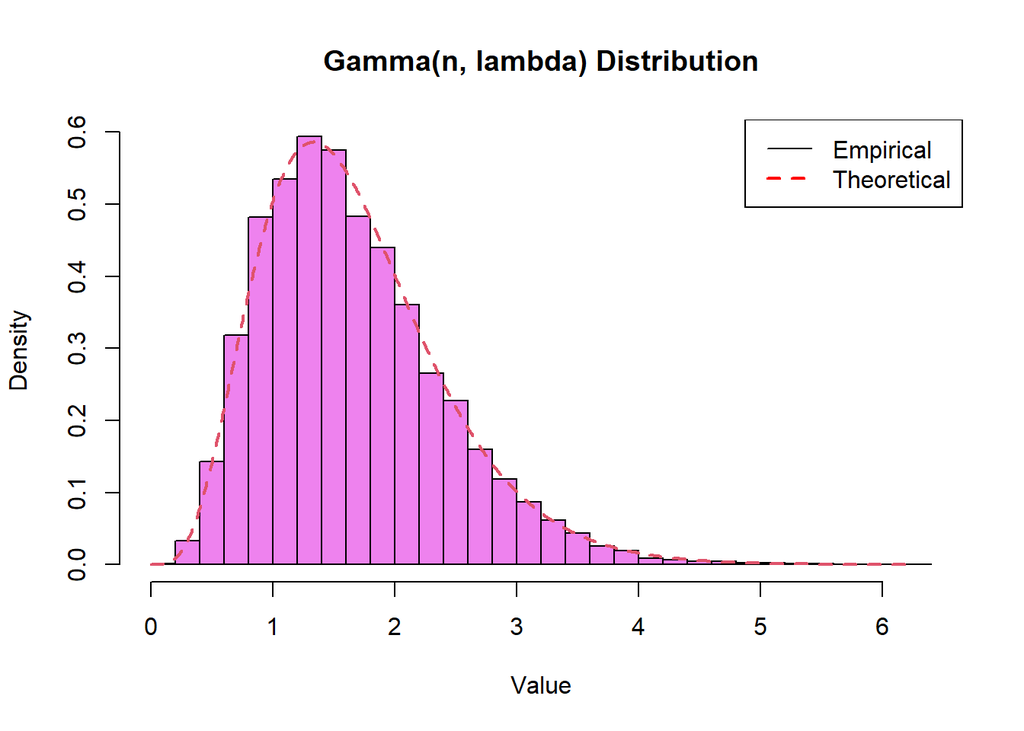

```r
set.seed(123)  # For reproducibility
n <- 5         # Shape parameter for gamma distribution
lambda <- 3    # Rate parameter

# Generate n * 10000 uniform random variables
x <- matrix(runif(n = n * 10000, min = 0, max = 1), ncol = n)

# Transform each column to exponential(lambda)
y_exp <- -(1/lambda) * log(1 - x)

# Sum the exponentials across rows to get gamma(n, lambda)
y_gamma <- rowSums(y_exp)

# Plot the histogram
hist(y_gamma, probability = TRUE, breaks = 30,
     main = "Gamma(n, lambda) Distribution",
     xlab = "Value", ylab = "Density",col = "violet")

# Add the theoretical gamma density curve
s <- seq(0, max(y_gamma), by = 0.01)
dgamma_vals <- dgamma(s, shape = n, rate = lambda)
lines(s, dgamma_vals, col = 2, lwd = 2, lty = 2)

# Add legend
legend("topright", legend = c("Empirical", "Theoretical"),
       col = c("black", "red"), lty = c(1, 2), lwd = c(1, 2))
```

$\textbf{Mathematical Foundation}$

$\textbf{Beta Distribution}$ A random variable $B$ follows a Beta distribution with parameters $\alpha$ and $\beta$ (denoted $B \sim \text{Beta}(\alpha, \beta)$) if its PDF is:
$$f_B(b) = \frac{b^{\alpha-1} (1-b)^{\beta-1}}{B(\alpha, \beta)}, \quad 0
\leq b \leq 1$$
where $B(\alpha, \beta) = \frac{\Gamma(\alpha)\Gamma(\beta)}{\Gamma(\alpha + \beta)}$ is the Beta function.

$\textbf{Transformation: Gamma to Beta}$

$\textbf{Key Theorem}$ If $X \sim \text{Gamma}(\alpha, \lambda)$ and $Y \sim \text{Gamma}(\beta, \lambda)$ are independent, then:
$$B = \frac{X}{X + Y} \sim \text{Beta}(\alpha, \beta)$$

$\textbf{Proof}$

1. $\textbf{Joint Distribution:}$ The joint PDF of $(X, Y)$ is:
   $$f_{X,Y}(x,y) = \frac{\lambda^\alpha x^{\alpha-1} e^{-\lambda
   x}}{\Gamma(\alpha)} \cdot \frac{\lambda^\beta y^{\beta-1} e^{-\lambda
   y}}{\Gamma(\beta)}$$
2. $\textbf{Variable Transformation:}$ Let $B = \frac{X}{X + Y}$ and $T = X + Y$. The inverse transformations are:
   $$X = BT, \quad Y = T(1 - B)$$
   The Jacobian determinant of this transformation is:
   $$J = \begin{vmatrix}
   \frac{\partial x}{\partial b} & \frac{\partial x}{\partial t} \\
   \frac{\partial y}{\partial b} & \frac{\partial y}{\partial t}
   \end{vmatrix} = \begin{vmatrix}
   t & b \\
   -t & 1 - b
   \end{vmatrix} = t(1 - b) + tb = t$$
3. $\textbf{New Joint PDF:}$ Substituting $(X, Y) = (b t, t(1 - b))$ into $f_{X,Y}$ and multiplying by $|J| = t$:
   $$f_{B,T}(b,t) = \frac{\lambda^{\alpha + \beta} (b t)^{\alpha-1} (t(1 -
   b))^{\beta-1} e^{-\lambda t}}{\Gamma(\alpha)\Gamma(\beta)} \cdot t$$
   Simplifying:
   $$f_{B,T}(b,t) = \underbrace{\frac{b^{\alpha-1} (1 -
   b)^{\beta-1}}{B(\alpha, \beta)}}_{\text{Beta PDF}} \cdot
   \underbrace{\frac{\lambda^{\alpha + \beta} t^{\alpha + \beta - 1}
   e^{-\lambda t}}{\Gamma(\alpha + \beta)}}_{\text{Gamma PDF}}$$

$\textbf{Marginal Distribution:}$ Since $f_{B,T}(b,t)$ factors into a Beta PDF in $b$ and a Gamma PDF in $t$, $B$ and $T$ are independent, and:
$$B \sim \text{Beta}(\alpha, \beta)$$

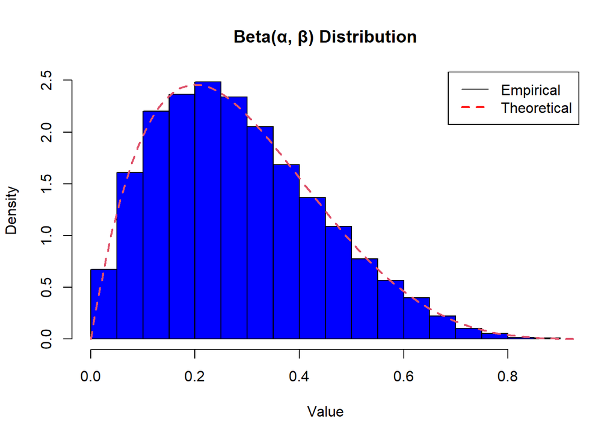

```r
set.seed(123)
alpha <- 2  # Shape parameter 1 for Beta
beta <- 5   # Shape parameter 2 for Beta
lambda <- 1 # Rate parameter (cancels out in normalization)

# Generate Gamma random variables
X <- rgamma(n = 10000, shape = alpha, rate = lambda)
Y <- rgamma(n = 10000, shape = beta, rate = lambda)

# Convert to Beta distribution
B <- X / (X + Y)

# Plot histogram
hist(B, probability = TRUE, breaks = 30,
     main = "Beta(α, β) Distribution",
     xlab = "Value", ylab = "Density",col = "blue")

# Overlay theoretical Beta density
s <- seq(0, 1, by = 0.01)
dbeta_vals <- dbeta(s, shape1 = alpha, shape2 = beta)
lines(s, dbeta_vals, col = 2, lwd = 2, lty = 2)

# Add legend
legend("topright", legend = c("Empirical", "Theoretical"),
       col = c("black", "red"), lty = c(1, 2), lwd = c(1, 2))
```

$\textbf{Mathematical Theory}$

$\textbf{Uniform Random Variables}$ Let $U \sim \text{Uniform}(0,1)$ be a continuous random variable with probability density function (PDF):
$$f_U(u) =
\begin{cases}
1 & \text{for } 0 \leq u \leq 1 \\
0 & \text{otherwise}
\end{cases}$$
and cumulative distribution function (CDF):
$$F_U(u) =
\begin{cases}
0 & \text{for } u < 0 \\
u & \text{for } 0 \leq u \leq 1 \\
1 & \text{for } u > 1
\end{cases}$$

$\textbf{Normal Random Variables}$ Let $Z \sim \mathcal{N}(0,1)$ be a standard normal random variable with PDF:
$$\phi(z) = \frac{1}{\sqrt{2\pi}} e^{-z^2/2}$$
and CDF:
$$\Phi(z) = \int_{-\infty}^z \phi(t) \, dt$$

$\textbf{Inverse Transform Method}$ The key mathematical result used in the transformation is the $\textbf{probability integral transform}:$

Theorem: If $U \sim \text{Uniform}(0,1)$ and $F$ is any CDF, then the random variable $X = F^{-1}(U)$ has CDF $F$.

Applying this to the normal distribution:
$$Z = \Phi^{-1}(U)$$
where $\Phi^{-1}$ is the quantile function of the standard normal distribution.

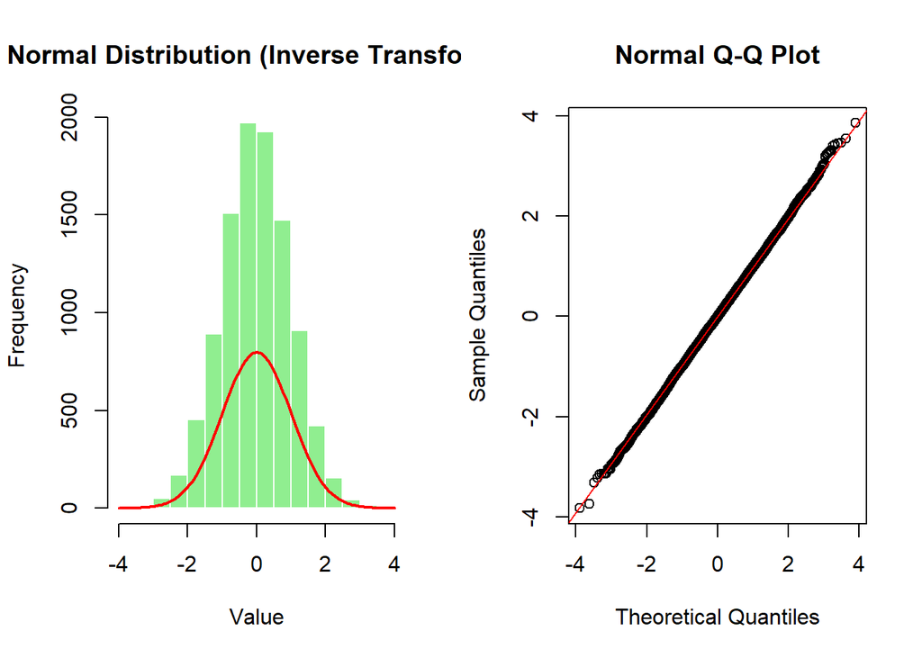

```r
# Set seed for reproducibility
set.seed(123)

# Generate 10,000 uniform random variables
uniform_data <- runif(10000, min = 0, max = 1)

# Transform to standard normal using inverse CDF (quantile function)
normal_data_inverse <- qnorm(uniform_data)

# Plot results
par(mfrow = c(1, 2))
hist(normal_data_inverse, main = "Normal Distribution (Inverse Transform)",
     xlab = "Value", col = "lightgreen", border = "white")

# Add theoretical normal curve
x <- seq(-4, 4, length.out = 100)
lines(x, dnorm(x) * 10000 * 0.2, col = "red", lwd = 2) # Scaling factor for visualization

# Q-Q plot to check normality
qqnorm(normal_data_inverse)
qqline(normal_data_inverse, col = "red")
```

$\textbf{Mathematical Foundation}$

Given $Z \sim \mathcal{N}(0,1)$, the squared standard normal random variable follows a chi-squared distribution:

$$Z^2 \sim \chi^2_1$$

where: 1. The $\chi^2_1$ distribution has 1 degree of freedom 2. Probability density function (PDF):
$$f(x) = \frac{1}{\sqrt{2\pi x}}e^{-x/2} \quad \text{for } x > 0$$
3. Mean: $\mathbb{E}[Z^2] = 1$ 4. Variance: $\text{Var}(Z^2) = 2$

$\textbf{Validation}$

$\textbf{Theoretical vs. Empirical Distribution}$ The histogram of squared values should match the $\chi^2_1$ density curve. The Q-Q plot compares sample quantiles with theoretical $\chi^2_1$ quantiles.

$\textbf{Hypothesis Testing}$ The Kolmogorov-Smirnov test statistic:
$$D = \sup_x |F_n(x) - F(x)|$$
where $F_n$ is the empirical CDF and $F$ is the theoretical $\chi^2_1$ CDF.

For $Z^2 \sim \chi^2_1$:
$$\begin{align*}
\text{Sample mean} &\approx \mathbb{E}[Z^2] = 1 \\
\text{Sample variance} &\approx \text{Var}(Z^2) = 2
\end{align*}$$

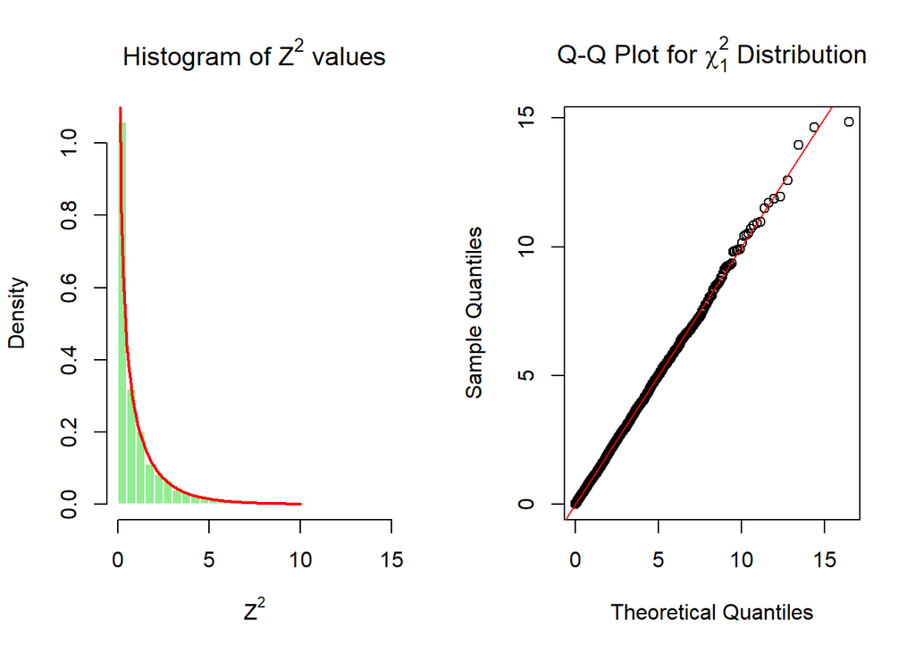

```r
# Continuing from previous normal distribution generation
set.seed(123)
uniform_data <- runif(10000, min = 0, max = 1)
normal_data <- qnorm(uniform_data)

# Create chi-squared distributed variables (1 degree of freedom)
chi_sq_data <- normal_data^2

# Plot the results
par(mfrow = c(1, 2))

# Histogram with theoretical density
hist(chi_sq_data, breaks = 50, probability = TRUE,
     main = expression(paste("Histogram of ", Z^2, " values")),
     xlab = expression(Z^2), col = "lightgreen", border = "white")

# Add theoretical chi-squared density (df=1)
curve(dchisq(x, df = 1), from = 0, to = 10,
      col = "red", lwd = 2, add = TRUE)

# Q-Q plot against theoretical chi-squared
qqplot(qchisq(ppoints(10000), df = 1), chi_sq_data,
       main = expression(paste("Q-Q Plot for ", chi[1]^2, " Distribution")),
       xlab = "Theoretical Quantiles",
       ylab = "Sample Quantiles")
abline(0, 1, col = "red")
```

```r
# Kolmogorov-Smirnov test
ks_test <- ks.test(chi_sq_data, "pchisq", df = 1)
print(ks_test)
```

```
##
##  Asymptotic one-sample Kolmogorov-Smirnov test
##
## data:  chi_sq_data
## D = 0.010887, p-value = 0.1867
## alternative hypothesis: two-sided
```

```r
# Mean and variance comparison
cat("Sample mean:", mean(chi_sq_data), "\n")
```

```
## Sample mean: 0.9841506
```

```r
cat("Theoretical mean (df=1):", 1, "\n")
```

```
## Theoretical mean (df=1): 1
```

```r
cat("Sample variance:", var(chi_sq_data), "\n")
```

```
## Sample variance: 1.974227
```

```r
cat("Theoretical variance (df=1):", 2, "\n")
```

```
## Theoretical variance (df=1): 2
```

$\textbf{Sum of Squared Normals}$

For $Z_i \overset{iid}{\sim} \mathcal{N}(0,1)$, the sum of their squares follows:

$$X = \sum_{i=1}^k Z_i^2 \sim \chi^2_k = \text{Gamma}\left(\frac{k}{2},
\frac{1}{2}\right)$$

$\textbf{Properties}$ 1. Shape parameter $\alpha = \frac{k}{2}$ 2. Rate parameter $\beta = \frac{1}{2}$ 3. Mean: $\mathbb{E}[X] = \frac{\alpha}{\beta} = k$ 4. Variance: $\text{Var}(X) = \frac{\alpha}{\beta^2} = 2k$

```r
# Continuing from previous normal distribution generation
set.seed(123)
uniform_data <- runif(10000, min = 0, max = 1)
normal_data <- qnorm(uniform_data)

### Using sum of squared normals
n <- 4  # Number of normals to sum (degrees of freedom)
k <- n   # Shape parameter for Gamma
theta <- 2  # Scale parameter (1/rate)

# Create Gamma distributed variables by summing squared normals
gamma_data1 <- replicate(10000, {
  sum(rnorm(n)^2)
})

# Theoretical Gamma parameters for this method
shape1 <- n/2
rate1 <- 1/2
### Visualization
par(mfrow = c(1, 2))

hist(gamma_data1, breaks = 50, probability = TRUE,
     main = expression(paste("Sum of ", n, " squared normals")),
     xlab = "Value", col = "lightblue")
curve(dgamma(x, shape = shape1, rate = rate1),
      col = "red", lwd = 2, add = TRUE)
### Comparison
cat("(Sum of squares):\n")
```

```
## (Sum of squares):
```

```r
cat("Sample mean:", mean(gamma_data1), "Theoretical:", shape1/rate1, "\n")
```

```
## Sample mean: 4.0031 Theoretical: 4
```

```r
cat("Sample variance:", var(gamma_data1), "Theoretical:", shape1/rate1^2, "\n\n")
```

```
## Sample variance: 7.798206 Theoretical: 8
```

```r
# KS tests
ks.test(gamma_data1, "pgamma", shape = shape1, rate = rate1)
```

```
##
##  Asymptotic one-sample Kolmogorov-Smirnov test
##
## data:  gamma_data1
## D = 0.0055881, p-value = 0.9137
## alternative hypothesis: two-sided
```

[figure not shown]